# xwMOOC 기계학습

저녁이 있는 삶 – 손학규

## 학습목표

> - 기본적인 한국어 텍스트 데이터 분석과정을 살펴본다.
> - 손학규 전 민주당 대표가 저술한 저녁이 있는 삶, 책 데이터를 분석한다.

## 책 데이터 분석 작업흐름

텍스트 책 데이터를 분석하는 과정은 영문 텍스트를 분석하는 것과 크게 다르지 않는다.

- 텍스트 분석을 위한 기반 팩키지를 설치.
  - `KoNLP`, `tm`, `wordcloud`, `RColorBrewer`
  - `KoNLP` 팩키지가 의존성을 갖는 `RSQLite` 및 `rJava`를 설치 및 설정
- 컴퓨터, 즉 R이 분석할 수 있도록 텍스트 데이터를 전처리.
- 시각화 및 고급 분석 기법을 통한 모형 개발

```r
# install.packages("KoNLP")
# install.packages("RSQLite")

# Sys.setenv(JAVA_HOME='C:\\Program Files\\Java\\jre1.8.0_102') # for 64-bit version

library(rJava)
library(KoNLP)
library(tidyverse)
library(RColorBrewer)
library(wordcloud)
library(tm)
library(stringr)
library(wordcloud2)
```

## `KoNLP` 팩키지

```r
# useNIADic()
useNIADic(which_dic = c("woorimalsam", "insighter"), category_dic_nms = "political", backup = T)
```

```
Backup was just finished!
984210 words dictionary was built.
```

## 저녁이 있는 삶

[저녁이 있는 삶 - 손학규의 민생경제론](https://www.kyobobook.co.kr/product/detailViewKor.laf?mallGb=KOR&ejkGb=KOR&barcode=9788992792318&orderClick=JAj)은 [손학규](http://www.hq.or.kr/main/) 전 민주당 대표가 2012년 대선을 준비하면서 펴낸 책으로 김종인 민주당 의원 [지금 왜 경제민주화인가 - 한국 경제의 미래를 위하여](http://www.kyobobook.co.kr/product/detailViewKor.laf?barcode=9788943103996)와 더불어 많이 회자되고 있는 책이다.

먼저 책 데이터를 불러온 다음, 한글 관련 내용만 추출하고 나서, 말뭉치 정제 과정을 거친다.

```r
book <- readLines("data/저녁이 있는 삶.txt", encoding="UTF-8")

# http://stackoverflow.com/questions/9637278/r-tm-package-invalid-input-in-utf8towcs
book <- str_replace_all(book,"[^[:graph:]]", " ")
book <- str_replace_all(book,"[^[ㄱ-흫]]", " ")
book <- book[which(book != "")]

book_corpus <- sapply(book, function(x) {paste(extractNoun(x), collapse=" ")}, USE.NAMES=F)

#말뭉치 정제과정
book_corpus <- Corpus(VectorSource(book_corpus))
book_corpus <- tm_map(book_corpus, removePunctuation)
book_corpus <- tm_map(book_corpus, removeNumbers)
book_corpus <- tm_map(book_corpus, tolower)
book_corpus <- tm_map(book_corpus, stripWhitespace)
book_stopwords <- c(stopwords("english"), "되", "하면", "것", "그것", "음", "수", "들이", "한", "할", "있", "년", "하기", "하지", "하")
book_corpus <-tm_map(book_corpus, removeWords, book_stopwords)
book_corpus <-tm_map(book_corpus, PlainTextDocument)

book_tdm <- TermDocumentMatrix(book_corpus, control=list(wordLengths=c(2,Inf)))
```

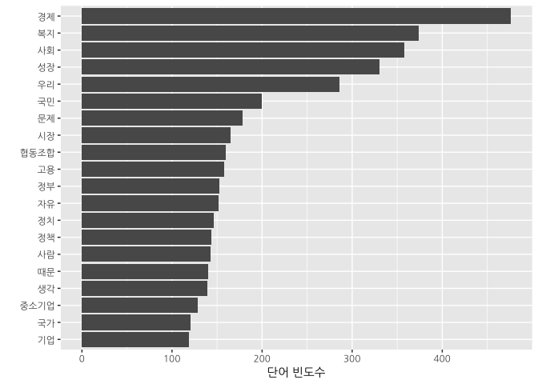

```r
#시각화---------------------------------------------------------------------
library(ggplot2)

book_term_freq <- rowSums(as.matrix(book_tdm))
book_term_freq <- subset(book_term_freq, book_term_freq >= 50)

book_term_df <- data.frame(term = names(book_term_freq), freq = book_term_freq) %>% arrange(desc(freq))

ggplot(book_term_df[1:20,], aes(reorder(term, freq), freq)) +
  geom_bar(stat="identity") + coord_flip() +
  ylab("단어 빈도수") +
  xlab("")
```

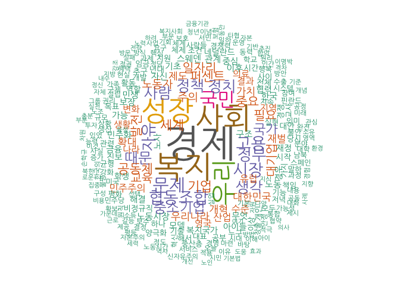

```r
m <- as.matrix(book_tdm)
wordFreq <- sort(rowSums(m), decreasing = TRUE)

pal <- brewer.pal(8, "Dark2")
wordcloud(words = names(wordFreq), freq = wordFreq, min.freq = 20, random.order = F,
          rot.per = 0.1, colors = pal, family="NanumGothic")
```

## 저녁이 있는 삶 - 형태소 분석

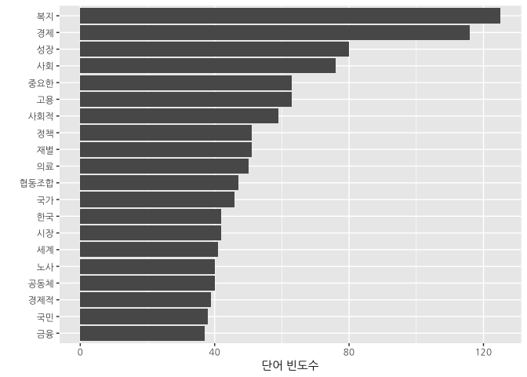

```r
book_lem <- sapply(book, SimplePos22, USE.NAMES = FALSE)
# NC 보통명사
book_lem_nc <- lapply(book_lem, function(x) grep("/NC", x, value=T))
book_lem_nc <- lapply(book_lem_nc, function(x) str_subset(x, "/NC$"))
book_lem_nc <- lapply(book_lem_nc, function(x) str_replace_all(x, "/NC", ""))
# NC 고유명사
book_lem_nq <- lapply(book_lem, function(x) grep("/NQ", x, value=T))
book_lem_nq <- lapply(book_lem_nq, function(x) str_subset(x, "/NQ$"))
book_lem_nq <- lapply(book_lem_nq, function(x) str_replace_all(x, "/NQ", ""))

book_corpus <- c(book_lem_nc, book_lem_nq)

#말뭉치 정제과정
book_corpus <- Corpus(VectorSource(book_corpus))
book_corpus <- tm_map(book_corpus, removePunctuation)
book_corpus <- tm_map(book_corpus, removeNumbers)
book_corpus <- tm_map(book_corpus, tolower)
book_corpus <- tm_map(book_corpus, stripWhitespace)
book_stopwords <- c(stopwords("english"),"이후", "없", "되", "하면", "것", "그것", "음", "수", "들이", "한", "할", "있", "년", "하기", "하지", "하")
book_corpus <-tm_map(book_corpus, removeWords, book_stopwords)
book_corpus <-tm_map(book_corpus, PlainTextDocument)

book_tdm <- TermDocumentMatrix(book_corpus, control=list(wordLengths=c(2,Inf)))
#시각화---------------------------------------------------------------------
library(ggplot2)

book_term_freq <- rowSums(as.matrix(book_tdm))
book_term_freq <- subset(book_term_freq, book_term_freq >= 20)

book_term_df <- data.frame(term = names(book_term_freq), freq = book_term_freq) %>% arrange(desc(freq))

ggplot(book_term_df[1:20,], aes(reorder(term, freq), freq)) +
  geom_bar(stat="identity") + coord_flip() +
  ylab("단어 빈도수") +
  xlab("")
```

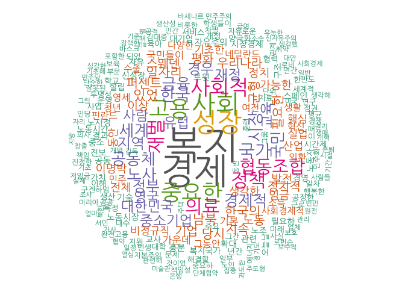

```r
m <- as.matrix(book_tdm)
wordFreq <- sort(rowSums(m), decreasing = TRUE)

pal <- brewer.pal(8, "Dark2")
wordcloud(words = names(wordFreq), freq = wordFreq, min.freq = 7, random.order = F,
          rot.per = 0.1, colors = pal, family="NanumGothic")
```

## 단어구름을 이미지와 결합

[‘저녁이 있는 삶’ 손학규 17일 국민의당 입당](http://sports.khan.co.kr/news/sk_index.html?art_id=201702161434003&sec_id=560901) 기사에 영감을 받아 국민의당 로고에 “저녁이 있는 삶” 단어를 넣으면 시각화로도 의미가 있어 보인다.

앞서 순차적으로 처리한 텍스트 전처리 명령어를 함수로 만들어 추상화를 하여 간결한 코드로 생성하고 나서 [`wordcloud2`](https://cran.r-project.org/web/packages/wordcloud2/vignettes/wordcloud.html) 팩키지의 기능 중 이미지를 **마스크(Mask)**로 삼아 시각화한다.

```r
# 1. 텍스트 전처리 함수
clean_text <- function(text){
  text <- str_replace_all(text,"[^[:graph:]]", " ")
  text <- str_replace_all(text,"[^[ㄱ-흫]]", " ")

    indexes <- which(text == "")
    if(length(indexes) > 0){
        text <- text[-indexes]
    }
    return(text)
}

clean_corpus <- function(corpus){
    corpus <- tm_map(corpus, stripWhitespace)
    corpus <- tm_map(corpus, removePunctuation)
    corpus <- tm_map(corpus, removeNumbers)
    corpus <- tm_map(corpus, removeWords, c(stopwords("en"), "되", "하면", "것", "그것", "음", "수", "들이", "한", "할", "있", "년", "하기", "하지", "하"))
    corpus <- tm_map(corpus, content_transformer(tolower))
    corpus <- tm_map(corpus, PlainTextDocument)
    return(corpus)
}

make_corpus <- function(text) {
    text_clean <- clean_text(text)
    text_source <- VectorSource(text_clean)
    text_corpus <- VCorpus(text_source)
    corpus <- clean_corpus(text_corpus)
}

word_freq <- function(corpus) {
    doc_tdm<- TermDocumentMatrix(corpus, control=list(wordLengths=c(2,Inf))) # 한글
    doc_m <- as.matrix(doc_tdm)
    doc_term_freq <- rowSums(doc_m)
    doc_word_freqs <- data.frame(term = names(doc_term_freq),
                                 num = doc_term_freq) %>% arrange(desc(num))
    return(doc_word_freqs)
}

# 2. 한글 데이터 정제 ----------------------------------------------------------------
book <- readLines("data/저녁이 있는 삶.txt", encoding="UTF-8")

book <- clean_text(book)

book_noun <- sapply(book, function(x) {paste(extractNoun(x), collapse=" ")}, USE.NAMES=F)

#말뭉치 정제과정

book_corpus <- make_corpus(book_noun)

book_corpus <- clean_corpus(book_corpus)

book_term_df <- word_freq(book_corpus)

#3. 시각화---------------------------------------------------------------------

rownames(book_term_df) <- book_term_df$term

wordcloud2(book_term_df, figPath = "data/people_logo.jpg", size = 1.1, color = "#006245", fontFamily ="AppleGothic")
```

[interactive chart not shown]